# Risk Factor Analysis

## Outcome Variable

**Outcome Variable:** whz

## Predictor Variables

**Intervention Variable:** hfoodsec

**Adjustment Set:**

unadjusted

## Stratifying Variables

The analysis was stratified on these variable(s):

- agecat
- studyid
- country

## Data Summary

| agecat | studyid | country | hfoodsec | n_cell | n |
| --- | --- | --- | --- | --- | --- |
| Birth | GMS-Nepal | NEPAL | Food Secure | 442 | 620 |
| Birth | GMS-Nepal | NEPAL | Mildly Food Insecure | 100 | 620 |
| Birth | GMS-Nepal | NEPAL | Food Insecure | 78 | 620 |
| Birth | JiVitA-3 | BANGLADESH | Food Secure | 5797 | 11763 |
| Birth | JiVitA-3 | BANGLADESH | Mildly Food Insecure | 3947 | 11763 |
| Birth | JiVitA-3 | BANGLADESH | Food Insecure | 2019 | 11763 |
| Birth | JiVitA-4 | BANGLADESH | Food Secure | 1205 | 2383 |
| Birth | JiVitA-4 | BANGLADESH | Mildly Food Insecure | 870 | 2383 |
| Birth | JiVitA-4 | BANGLADESH | Food Insecure | 308 | 2383 |
| Birth | MAL-ED | BANGLADESH | Food Secure | 138 | 162 |
| Birth | MAL-ED | BANGLADESH | Mildly Food Insecure | 3 | 162 |
| Birth | MAL-ED | BANGLADESH | Food Insecure | 21 | 162 |
| Birth | MAL-ED | BRAZIL | Food Secure | 0 | 26 |
| Birth | MAL-ED | BRAZIL | Mildly Food Insecure | 4 | 26 |
| Birth | MAL-ED | BRAZIL | Food Insecure | 22 | 26 |
| Birth | MAL-ED | INDIA | Food Secure | 32 | 35 |
| Birth | MAL-ED | INDIA | Mildly Food Insecure | 1 | 35 |
| Birth | MAL-ED | INDIA | Food Insecure | 2 | 35 |
| Birth | MAL-ED | NEPAL | Food Secure | 10 | 14 |
| Birth | MAL-ED | NEPAL | Mildly Food Insecure | 1 | 14 |
| Birth | MAL-ED | NEPAL | Food Insecure | 3 | 14 |
| Birth | MAL-ED | PERU | Food Secure | 23 | 89 |
| Birth | MAL-ED | PERU | Mildly Food Insecure | 22 | 89 |
| Birth | MAL-ED | PERU | Food Insecure | 44 | 89 |
| Birth | MAL-ED | SOUTH AFRICA | Food Secure | 45 | 87 |
| Birth | MAL-ED | SOUTH AFRICA | Mildly Food Insecure | 9 | 87 |
| Birth | MAL-ED | SOUTH AFRICA | Food Insecure | 33 | 87 |
| Birth | NIH-Birth | BANGLADESH | Food Secure | 86 | 575 |
| Birth | NIH-Birth | BANGLADESH | Mildly Food Insecure | 453 | 575 |
| Birth | NIH-Birth | BANGLADESH | Food Insecure | 36 | 575 |

[output cut: 69 more lines]

The following strata were considered:

- agecat: 24 months, studyid: GMS-Nepal, country: NEPAL
- agecat: 24 months, studyid: JiVitA-3, country: BANGLADESH
- agecat: 24 months, studyid: JiVitA-4, country: BANGLADESH
- agecat: 24 months, studyid: MAL-ED, country: BANGLADESH
- agecat: 24 months, studyid: MAL-ED, country: BRAZIL
- agecat: 24 months, studyid: MAL-ED, country: INDIA
- agecat: 24 months, studyid: MAL-ED, country: NEPAL
- agecat: 24 months, studyid: MAL-ED, country: PERU
- agecat: 24 months, studyid: MAL-ED, country: SOUTH AFRICA
- agecat: 24 months, studyid: NIH-Birth, country: BANGLADESH
- agecat: 24 months, studyid: NIH-Crypto, country: BANGLADESH
- agecat: 6 months, studyid: GMS-Nepal, country: NEPAL
- agecat: 6 months, studyid: JiVitA-3, country: BANGLADESH
- agecat: 6 months, studyid: JiVitA-4, country: BANGLADESH
- agecat: 6 months, studyid: MAL-ED, country: BANGLADESH
- agecat: 6 months, studyid: MAL-ED, country: BRAZIL
- agecat: 6 months, studyid: MAL-ED, country: INDIA
- agecat: 6 months, studyid: MAL-ED, country: NEPAL
- agecat: 6 months, studyid: MAL-ED, country: PERU
- agecat: 6 months, studyid: MAL-ED, country: SOUTH AFRICA
- agecat: 6 months, studyid: NIH-Birth, country: BANGLADESH
- agecat: 6 months, studyid: NIH-Crypto, country: BANGLADESH
- agecat: Birth, studyid: GMS-Nepal, country: NEPAL
- agecat: Birth, studyid: JiVitA-3, country: BANGLADESH
- agecat: Birth, studyid: JiVitA-4, country: BANGLADESH
- agecat: Birth, studyid: MAL-ED, country: BANGLADESH
- agecat: Birth, studyid: MAL-ED, country: BRAZIL
- agecat: Birth, studyid: MAL-ED, country: INDIA
- agecat: Birth, studyid: MAL-ED, country: NEPAL
- agecat: Birth, studyid: MAL-ED, country: PERU
- agecat: Birth, studyid: MAL-ED, country: SOUTH AFRICA
- agecat: Birth, studyid: NIH-Birth, country: BANGLADESH
- agecat: Birth, studyid: NIH-Crypto, country: BANGLADESH

### Dropped Strata

Some strata were dropped due to rare outcomes:

- agecat: Birth, studyid: MAL-ED, country: BANGLADESH
- agecat: Birth, studyid: MAL-ED, country: BRAZIL
- agecat: Birth, studyid: MAL-ED, country: INDIA
- agecat: Birth, studyid: MAL-ED, country: NEPAL
- agecat: 6 months, studyid: MAL-ED, country: BANGLADESH
- agecat: 6 months, studyid: MAL-ED, country: BRAZIL
- agecat: 24 months, studyid: MAL-ED, country: BANGLADESH
- agecat: 24 months, studyid: MAL-ED, country: BRAZIL

## Methods Detail

We’re interested in the causal parameters $E[Y_a]$ for all values of $a \in \mathcal{A}$. These parameters represent the mean outcome if, possibly contrary to fact, we intervened to set all units to have $A=a$. Under the randomization and positivity assumptions, these are identified by the statistical parameters $\psi_a=E_W[E_{Y|A,W}(Y|A=a,W)]$. In addition, we’re interested in the mean of $Y$, $E[Y]$ under no intervention (the observed mean). We will estimate these parameters by using SuperLearner to fit the relevant likelihood factors – $E_{Y|A,W}(Y|A=a,W)$ and $p(A=a|W)$, and then updating our likelihood fit using a joint TMLE.

For unadjusted analyses ($W=\{\}$), initial likelihoods were estimated using Lrnr_glm to estimate the simple $E(Y|A)$ and Lrnr_mean to estimate $p(A)$. For adjusted analyses, a small library containing Lrnr_glmnet, Lrnr_xgboost, and Lrnr_mean was used.

Having estimated these parameters, we will then use the delta method to estimate relative risks and attributable risks relative to a prespecified baseline level of $A$.

# Results Detail

## Results Plots

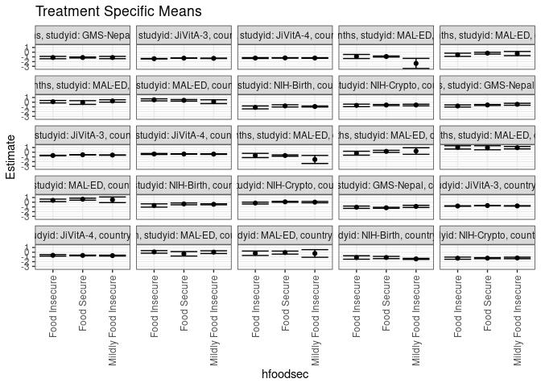

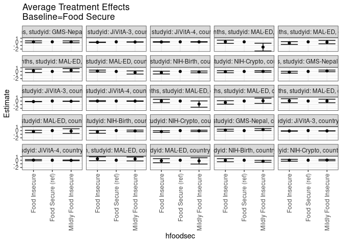

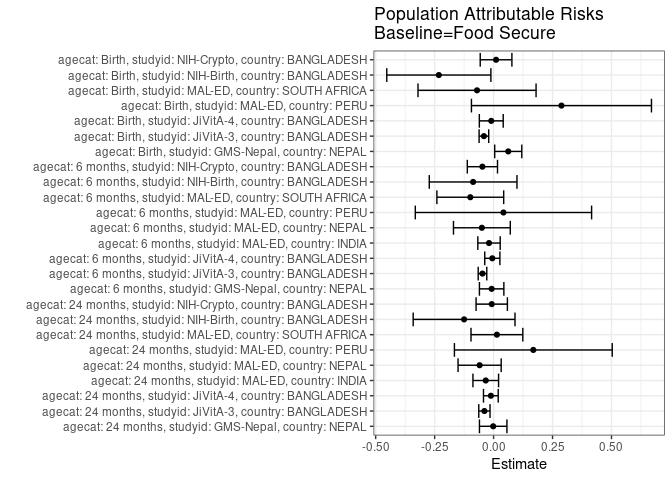

## Results Table

### Parameter: TSM

| agecat | studyid | country | intervention_level | baseline_level | estimate | ci_lower | ci_upper |
| --- | --- | --- | --- | --- | --- | --- | --- |
| Birth | GMS-Nepal | NEPAL | Food Secure | NA | -1.1786425 | -1.2829329 | -1.0743521 |
| Birth | GMS-Nepal | NEPAL | Mildly Food Insecure | NA | -0.8876000 | -1.1172935 | -0.6579065 |
| Birth | GMS-Nepal | NEPAL | Food Insecure | NA | -1.0579487 | -1.3039500 | -0.8119474 |
| Birth | JiVitA-3 | BANGLADESH | Food Secure | NA | -0.7097740 | -0.7396027 | -0.6799453 |
| Birth | JiVitA-3 | BANGLADESH | Mildly Food Insecure | NA | -0.7821890 | -0.8189849 | -0.7453931 |
| Birth | JiVitA-3 | BANGLADESH | Food Insecure | NA | -0.8077415 | -0.8554328 | -0.7600501 |
| Birth | JiVitA-4 | BANGLADESH | Food Secure | NA | -0.6799917 | -0.7469909 | -0.6129925 |
| Birth | JiVitA-4 | BANGLADESH | Mildly Food Insecure | NA | -0.7162414 | -0.8042279 | -0.6282549 |
| Birth | JiVitA-4 | BANGLADESH | Food Insecure | NA | -0.6536039 | -0.8220178 | -0.4851900 |
| Birth | MAL-ED | PERU | Food Secure | NA | -0.3360870 | -0.8044655 | 0.1322916 |
| Birth | MAL-ED | PERU | Mildly Food Insecure | NA | 0.0177273 | -0.2707152 | 0.3061698 |
| Birth | MAL-ED | PERU | Food Insecure | NA | 0.0690909 | -0.2074637 | 0.3456455 |
| Birth | MAL-ED | SOUTH AFRICA | Food Secure | NA | -0.0800000 | -0.4003913 | 0.2403913 |
| Birth | MAL-ED | SOUTH AFRICA | Mildly Food Insecure | NA | -0.2611111 | -1.0678216 | 0.5455994 |
| Birth | MAL-ED | SOUTH AFRICA | Food Insecure | NA | -0.2157576 | -0.6840291 | 0.2525139 |
| Birth | NIH-Birth | BANGLADESH | Food Secure | NA | -1.1176744 | -1.3559750 | -0.8793739 |
| Birth | NIH-Birth | BANGLADESH | Mildly Food Insecure | NA | -1.4123510 | -1.5189852 | -1.3057168 |
| Birth | NIH-Birth | BANGLADESH | Food Insecure | NA | -1.1191667 | -1.4810756 | -0.7572577 |
| Birth | NIH-Crypto | BANGLADESH | Food Secure | NA | -1.2546270 | -1.3636642 | -1.1455899 |
| Birth | NIH-Crypto | BANGLADESH | Mildly Food Insecure | NA | -1.2136181 | -1.3731301 | -1.0541060 |
| Birth | NIH-Crypto | BANGLADESH | Food Insecure | NA | -1.2641772 | -1.4930804 | -1.0352740 |
| 6 months | GMS-Nepal | NEPAL | Food Secure | NA | -0.5936153 | -0.6983811 | -0.4888495 |
| 6 months | GMS-Nepal | NEPAL | Mildly Food Insecure | NA | -0.4469079 | -0.6566443 | -0.2371715 |
| 6 months | GMS-Nepal | NEPAL | Food Insecure | NA | -0.8052703 | -1.0315344 | -0.5790062 |
| 6 months | JiVitA-3 | BANGLADESH | Food Secure | NA | -0.5461279 | -0.5738473 | -0.5184085 |
| 6 months | JiVitA-3 | BANGLADESH | Mildly Food Insecure | NA | -0.6116959 | -0.6417186 | -0.5816732 |
| 6 months | JiVitA-3 | BANGLADESH | Food Insecure | NA | -0.6984305 | -0.7418746 | -0.6549864 |
| 6 months | JiVitA-4 | BANGLADESH | Food Secure | NA | -0.3841391 | -0.4325457 | -0.3357325 |
| 6 months | JiVitA-4 | BANGLADESH | Mildly Food Insecure | NA | -0.4003935 | -0.4584618 | -0.3423253 |
| 6 months | JiVitA-4 | BANGLADESH | Food Insecure | NA | -0.3807154 | -0.4897478 | -0.2716830 |
| 6 months | MAL-ED | INDIA | Food Secure | NA | -0.7025789 | -0.8453715 | -0.5597864 |
| 6 months | MAL-ED | INDIA | Mildly Food Insecure | NA | -1.5420000 | -2.3989104 | -0.6850896 |
| 6 months | MAL-ED | INDIA | Food Insecure | NA | -0.6978922 | -1.1435259 | -0.2522584 |
| 6 months | MAL-ED | NEPAL | Food Secure | NA | 0.1774468 | -0.0422755 | 0.3971691 |
| 6 months | MAL-ED | NEPAL | Mildly Food Insecure | NA | 0.2483333 | -0.4452208 | 0.9418875 |
| 6 months | MAL-ED | NEPAL | Food Insecure | NA | -0.2131579 | -0.6322034 | 0.2058876 |
| 6 months | MAL-ED | PERU | Food Secure | NA | 0.9401235 | 0.5128964 | 1.3673505 |
| 6 months | MAL-ED | PERU | Mildly Food Insecure | NA | 0.9528571 | 0.6978859 | 1.2078284 |
| 6 months | MAL-ED | PERU | Food Insecure | NA | 1.0166369 | 0.6674831 | 1.3657907 |
| 6 months | MAL-ED | SOUTH AFRICA | Food Secure | NA | 0.6417313 | 0.4274668 | 0.8559957 |
| 6 months | MAL-ED | SOUTH AFRICA | Mildly Food Insecure | NA | 0.5123148 | -0.0861454 | 1.1107750 |
| 6 months | MAL-ED | SOUTH AFRICA | Food Insecure | NA | 0.3923045 | 0.1261781 | 0.6584309 |
| 6 months | NIH-Birth | BANGLADESH | Food Secure | NA | -0.3605625 | -0.5544734 | -0.1666516 |
| 6 months | NIH-Birth | BANGLADESH | Mildly Food Insecure | NA | -0.4405056 | -0.5453329 | -0.3356783 |
| 6 months | NIH-Birth | BANGLADESH | Food Insecure | NA | -0.6930000 | -1.0413117 | -0.3446883 |
| 6 months | NIH-Crypto | BANGLADESH | Food Secure | NA | 0.0772014 | -0.0274914 | 0.1818942 |
| 6 months | NIH-Crypto | BANGLADESH | Mildly Food Insecure | NA | 0.0163725 | -0.1308515 | 0.1635966 |
| 6 months | NIH-Crypto | BANGLADESH | Food Insecure | NA | -0.1788690 | -0.3732511 | 0.0155130 |
| 24 months | GMS-Nepal | NEPAL | Food Secure | NA | -1.1287928 | -1.2335041 | -1.0240815 |
| 24 months | GMS-Nepal | NEPAL | Mildly Food Insecure | NA | -1.1330597 | -1.3765529 | -0.8895665 |
| 24 months | GMS-Nepal | NEPAL | Food Insecure | NA | -1.1364493 | -1.3887075 | -0.8841910 |
| 24 months | JiVitA-3 | BANGLADESH | Food Secure | NA | -1.2598418 | -1.2934515 | -1.2262322 |
| 24 months | JiVitA-3 | BANGLADESH | Mildly Food Insecure | NA | -1.3052234 | -1.3457662 | -1.2646806 |
| 24 months | JiVitA-3 | BANGLADESH | Food Insecure | NA | -1.3828924 | -1.4302599 | -1.3355249 |
| 24 months | JiVitA-4 | BANGLADESH | Food Secure | NA | -1.2127585 | -1.2572363 | -1.1682806 |
| 24 months | JiVitA-4 | BANGLADESH | Mildly Food Insecure | NA | -1.2339023 | -1.2895279 | -1.1782766 |
| 24 months | JiVitA-4 | BANGLADESH | Food Insecure | NA | -1.2432730 | -1.3240021 | -1.1625440 |
| 24 months | MAL-ED | INDIA | Food Secure | NA | -0.9256316 | -1.0440690 | -0.8071941 |
| 24 months | MAL-ED | INDIA | Mildly Food Insecure | NA | -2.3840000 | -3.4554070 | -1.3125930 |
| 24 months | MAL-ED | INDIA | Food Insecure | NA | -0.9111765 | -1.3418053 | -0.4805476 |
| 24 months | MAL-ED | NEPAL | Food Secure | NA | -0.2137766 | -0.4104542 | -0.0170990 |
| 24 months | MAL-ED | NEPAL | Mildly Food Insecure | NA | -0.2906667 | -0.7322845 | 0.1509512 |
| 24 months | MAL-ED | NEPAL | Food Insecure | NA | -0.5523684 | -0.8908812 | -0.2138556 |
| 24 months | MAL-ED | PERU | Food Secure | NA | -0.0702564 | -0.4657229 | 0.3252101 |
| 24 months | MAL-ED | PERU | Mildly Food Insecure | NA | 0.2582407 | 0.0077747 | 0.5087068 |
| 24 months | MAL-ED | PERU | Food Insecure | NA | 0.0992901 | -0.1654887 | 0.3640690 |
| 24 months | MAL-ED | SOUTH AFRICA | Food Secure | NA | 0.3939470 | 0.2286188 | 0.5592753 |
| 24 months | MAL-ED | SOUTH AFRICA | Mildly Food Insecure | NA | 0.1058333 | -0.2939661 | 0.5056327 |
| 24 months | MAL-ED | SOUTH AFRICA | Food Insecure | NA | 0.4975926 | 0.2840794 | 0.7111057 |
| 24 months | NIH-Birth | BANGLADESH | Food Secure | NA | -0.7864461 | -1.0193808 | -0.5535114 |
| 24 months | NIH-Birth | BANGLADESH | Mildly Food Insecure | NA | -0.9180505 | -1.0321622 | -0.8039387 |
| 24 months | NIH-Birth | BANGLADESH | Food Insecure | NA | -1.1053030 | -1.4148575 | -0.7957485 |
| 24 months | NIH-Crypto | BANGLADESH | Food Secure | NA | -0.6024850 | -0.7257444 | -0.4792256 |
| 24 months | NIH-Crypto | BANGLADESH | Mildly Food Insecure | NA | -0.5987903 | -0.7700446 | -0.4275361 |
| 24 months | NIH-Crypto | BANGLADESH | Food Insecure | NA | -0.6828571 | -0.9480378 | -0.4176765 |

### Parameter: E(Y)

| agecat | studyid | country | intervention_level | baseline_level | estimate | ci_lower | ci_upper |
| --- | --- | --- | --- | --- | --- | --- | --- |
| Birth | GMS-Nepal | NEPAL | NA | NA | -1.1165161 | -1.2055683 | -1.0274639 |
| Birth | JiVitA-3 | BANGLADESH | NA | NA | -0.7508875 | -0.7730765 | -0.7286985 |
| Birth | JiVitA-4 | BANGLADESH | NA | NA | -0.6898154 | -0.7422632 | -0.6373675 |
| Birth | MAL-ED | PERU | NA | NA | -0.0483146 | -0.2475806 | 0.1509514 |
| Birth | MAL-ED | SOUTH AFRICA | NA | NA | -0.1502299 | -0.4075620 | 0.1071022 |
| Birth | NIH-Birth | BANGLADESH | NA | NA | -1.3499217 | -1.4444634 | -1.2553801 |
| Birth | NIH-Crypto | BANGLADESH | NA | NA | -1.2441513 | -1.3281130 | -1.1601897 |
| 6 months | GMS-Nepal | NEPAL | NA | NA | -0.6018803 | -0.6892284 | -0.5145323 |
| 6 months | JiVitA-3 | BANGLADESH | NA | NA | -0.5932301 | -0.6127836 | -0.5736767 |
| 6 months | JiVitA-4 | BANGLADESH | NA | NA | -0.3895527 | -0.4270314 | -0.3520739 |
| 6 months | MAL-ED | INDIA | NA | NA | -0.7220008 | -0.8576809 | -0.5863207 |
| 6 months | MAL-ED | NEPAL | NA | NA | 0.1277734 | -0.0649431 | 0.3204900 |
| 6 months | MAL-ED | PERU | NA | NA | 0.9819369 | 0.7674415 | 1.1964324 |
| 6 months | MAL-ED | SOUTH AFRICA | NA | NA | 0.5429020 | 0.3813518 | 0.7044523 |
| 6 months | NIH-Birth | BANGLADESH | NA | NA | -0.4474038 | -0.5378167 | -0.3569909 |
| 6 months | NIH-Crypto | BANGLADESH | NA | NA | 0.0297622 | -0.0491685 | 0.1086930 |
| 24 months | GMS-Nepal | NEPAL | NA | NA | -1.1304997 | -1.2205265 | -1.0404728 |
| 24 months | JiVitA-3 | BANGLADESH | NA | NA | -1.2988352 | -1.3224626 | -1.2752078 |
| 24 months | JiVitA-4 | BANGLADESH | NA | NA | -1.2243590 | -1.2566569 | -1.1920612 |
| 24 months | MAL-ED | INDIA | NA | NA | -0.9588679 | -1.0774868 | -0.8402491 |
| 24 months | MAL-ED | NEPAL | NA | NA | -0.2730469 | -0.4358169 | -0.1102769 |
| 24 months | MAL-ED | PERU | NA | NA | 0.0982009 | -0.0794754 | 0.2758773 |
| 24 months | MAL-ED | SOUTH AFRICA | NA | NA | 0.4080227 | 0.2828348 | 0.5332106 |
| 24 months | NIH-Birth | BANGLADESH | NA | NA | -0.9115790 | -1.0095022 | -0.8136559 |
| 24 months | NIH-Crypto | BANGLADESH | NA | NA | -0.6103502 | -0.7050157 | -0.5156847 |

### Parameter: ATE

| agecat | studyid | country | intervention_level | baseline_level | estimate | ci_lower | ci_upper |
| --- | --- | --- | --- | --- | --- | --- | --- |
| Birth | GMS-Nepal | NEPAL | Food Secure | Food Secure | 0.0000000 | 0.0000000 | 0.0000000 |
| Birth | GMS-Nepal | NEPAL | Mildly Food Insecure | Food Secure | 0.2910425 | 0.0387816 | 0.5433035 |
| Birth | GMS-Nepal | NEPAL | Food Insecure | Food Secure | 0.1206938 | -0.1465011 | 0.3878888 |
| Birth | JiVitA-3 | BANGLADESH | Food Secure | Food Secure | 0.0000000 | 0.0000000 | 0.0000000 |
| Birth | JiVitA-3 | BANGLADESH | Mildly Food Insecure | Food Secure | -0.0724150 | -0.1178891 | -0.0269409 |
| Birth | JiVitA-3 | BANGLADESH | Food Insecure | Food Secure | -0.0979674 | -0.1522528 | -0.0436821 |
| Birth | JiVitA-4 | BANGLADESH | Food Secure | Food Secure | 0.0000000 | 0.0000000 | 0.0000000 |
| Birth | JiVitA-4 | BANGLADESH | Mildly Food Insecure | Food Secure | -0.0362497 | -0.1458337 | 0.0733343 |
| Birth | JiVitA-4 | BANGLADESH | Food Insecure | Food Secure | 0.0263878 | -0.1536597 | 0.2064353 |
| Birth | MAL-ED | PERU | Food Secure | Food Secure | 0.0000000 | 0.0000000 | 0.0000000 |
| Birth | MAL-ED | PERU | Mildly Food Insecure | Food Secure | 0.3538142 | -0.1962562 | 0.9038847 |
| Birth | MAL-ED | PERU | Food Insecure | Food Secure | 0.4051779 | -0.1387531 | 0.9491088 |
| Birth | MAL-ED | SOUTH AFRICA | Food Secure | Food Secure | 0.0000000 | 0.0000000 | 0.0000000 |
| Birth | MAL-ED | SOUTH AFRICA | Mildly Food Insecure | Food Secure | -0.1811111 | -1.0491159 | 0.6868937 |
| Birth | MAL-ED | SOUTH AFRICA | Food Insecure | Food Secure | -0.1357576 | -0.7031452 | 0.4316301 |
| Birth | NIH-Birth | BANGLADESH | Food Secure | Food Secure | 0.0000000 | 0.0000000 | 0.0000000 |
| Birth | NIH-Birth | BANGLADESH | Mildly Food Insecure | Food Secure | -0.2946766 | -0.5557475 | -0.0336057 |
| Birth | NIH-Birth | BANGLADESH | Food Insecure | Food Secure | -0.0014922 | -0.4348111 | 0.4318266 |
| Birth | NIH-Crypto | BANGLADESH | Food Secure | Food Secure | 0.0000000 | 0.0000000 | 0.0000000 |
| Birth | NIH-Crypto | BANGLADESH | Mildly Food Insecure | Food Secure | 0.0410089 | -0.1522090 | 0.2342269 |
| Birth | NIH-Crypto | BANGLADESH | Food Insecure | Food Secure | -0.0095502 | -0.2630966 | 0.2439962 |
| 6 months | GMS-Nepal | NEPAL | Food Secure | Food Secure | 0.0000000 | 0.0000000 | 0.0000000 |
| 6 months | GMS-Nepal | NEPAL | Mildly Food Insecure | Food Secure | 0.1467074 | -0.0877392 | 0.3811541 |
| 6 months | GMS-Nepal | NEPAL | Food Insecure | Food Secure | -0.2116550 | -0.4609967 | 0.0376868 |
| 6 months | JiVitA-3 | BANGLADESH | Food Secure | Food Secure | 0.0000000 | 0.0000000 | 0.0000000 |
| 6 months | JiVitA-3 | BANGLADESH | Mildly Food Insecure | Food Secure | -0.0655680 | -0.1054453 | -0.0256907 |
| 6 months | JiVitA-3 | BANGLADESH | Food Insecure | Food Secure | -0.1523026 | -0.2018357 | -0.1027695 |
| 6 months | JiVitA-4 | BANGLADESH | Food Secure | Food Secure | 0.0000000 | 0.0000000 | 0.0000000 |
| 6 months | JiVitA-4 | BANGLADESH | Mildly Food Insecure | Food Secure | -0.0162545 | -0.0877010 | 0.0551921 |
| 6 months | JiVitA-4 | BANGLADESH | Food Insecure | Food Secure | 0.0034236 | -0.1123099 | 0.1191572 |
| 6 months | MAL-ED | INDIA | Food Secure | Food Secure | 0.0000000 | 0.0000000 | 0.0000000 |
| 6 months | MAL-ED | INDIA | Mildly Food Insecure | Food Secure | -0.8394211 | -1.7081472 | 0.0293051 |
| 6 months | MAL-ED | INDIA | Food Insecure | Food Secure | 0.0046868 | -0.4632653 | 0.4726389 |
| 6 months | MAL-ED | NEPAL | Food Secure | Food Secure | 0.0000000 | 0.0000000 | 0.0000000 |
| 6 months | MAL-ED | NEPAL | Mildly Food Insecure | Food Secure | 0.0708865 | -0.6566403 | 0.7984133 |
| 6 months | MAL-ED | NEPAL | Food Insecure | Food Secure | -0.3906047 | -0.8637612 | 0.0825518 |
| 6 months | MAL-ED | PERU | Food Secure | Food Secure | 0.0000000 | 0.0000000 | 0.0000000 |
| 6 months | MAL-ED | PERU | Mildly Food Insecure | Food Secure | 0.0127337 | -0.4847935 | 0.5102608 |
| 6 months | MAL-ED | PERU | Food Insecure | Food Secure | 0.0765134 | -0.4752395 | 0.6282664 |
| 6 months | MAL-ED | SOUTH AFRICA | Food Secure | Food Secure | 0.0000000 | 0.0000000 | 0.0000000 |
| 6 months | MAL-ED | SOUTH AFRICA | Mildly Food Insecure | Food Secure | -0.1294165 | -0.7650766 | 0.5062437 |
| 6 months | MAL-ED | SOUTH AFRICA | Food Insecure | Food Secure | -0.2494267 | -0.5910881 | 0.0922347 |
| 6 months | NIH-Birth | BANGLADESH | Food Secure | Food Secure | 0.0000000 | 0.0000000 | 0.0000000 |
| 6 months | NIH-Birth | BANGLADESH | Mildly Food Insecure | Food Secure | -0.0799431 | -0.3003749 | 0.1404887 |
| 6 months | NIH-Birth | BANGLADESH | Food Insecure | Food Secure | -0.3324375 | -0.7310883 | 0.0662133 |
| 6 months | NIH-Crypto | BANGLADESH | Food Secure | Food Secure | 0.0000000 | 0.0000000 | 0.0000000 |
| 6 months | NIH-Crypto | BANGLADESH | Mildly Food Insecure | Food Secure | -0.0608289 | -0.2414819 | 0.1198242 |
| 6 months | NIH-Crypto | BANGLADESH | Food Insecure | Food Secure | -0.2560705 | -0.4768531 | -0.0352878 |
| 24 months | GMS-Nepal | NEPAL | Food Secure | Food Secure | 0.0000000 | 0.0000000 | 0.0000000 |
| 24 months | GMS-Nepal | NEPAL | Mildly Food Insecure | Food Secure | -0.0042669 | -0.2693205 | 0.2607866 |
| 24 months | GMS-Nepal | NEPAL | Food Insecure | Food Secure | -0.0076565 | -0.2807841 | 0.2654711 |
| 24 months | JiVitA-3 | BANGLADESH | Food Secure | Food Secure | 0.0000000 | 0.0000000 | 0.0000000 |
| 24 months | JiVitA-3 | BANGLADESH | Mildly Food Insecure | Food Secure | -0.0453815 | -0.0971887 | 0.0064256 |
| 24 months | JiVitA-3 | BANGLADESH | Food Insecure | Food Secure | -0.1230506 | -0.1798804 | -0.0662207 |
| 24 months | JiVitA-4 | BANGLADESH | Food Secure | Food Secure | 0.0000000 | 0.0000000 | 0.0000000 |
| 24 months | JiVitA-4 | BANGLADESH | Mildly Food Insecure | Food Secure | -0.0211438 | -0.0916223 | 0.0493346 |
| 24 months | JiVitA-4 | BANGLADESH | Food Insecure | Food Secure | -0.0305145 | -0.1229812 | 0.0619521 |
| 24 months | MAL-ED | INDIA | Food Secure | Food Secure | 0.0000000 | 0.0000000 | 0.0000000 |
| 24 months | MAL-ED | INDIA | Mildly Food Insecure | Food Secure | -1.4583684 | -2.5363018 | -0.3804350 |
| 24 months | MAL-ED | INDIA | Food Insecure | Food Secure | 0.0144551 | -0.4321640 | 0.4610742 |
| 24 months | MAL-ED | NEPAL | Food Secure | Food Secure | 0.0000000 | 0.0000000 | 0.0000000 |
| 24 months | MAL-ED | NEPAL | Mildly Food Insecure | Food Secure | -0.0768901 | -0.5603241 | 0.4065439 |
| 24 months | MAL-ED | NEPAL | Food Insecure | Food Secure | -0.3385918 | -0.7300928 | 0.0529091 |
| 24 months | MAL-ED | PERU | Food Secure | Food Secure | 0.0000000 | 0.0000000 | 0.0000000 |
| 24 months | MAL-ED | PERU | Mildly Food Insecure | Food Secure | 0.3284972 | -0.1396129 | 0.7966072 |
| 24 months | MAL-ED | PERU | Food Insecure | Food Secure | 0.1695465 | -0.3063753 | 0.6454684 |
| 24 months | MAL-ED | SOUTH AFRICA | Food Secure | Food Secure | 0.0000000 | 0.0000000 | 0.0000000 |
| 24 months | MAL-ED | SOUTH AFRICA | Mildly Food Insecure | Food Secure | -0.2881137 | -0.7207486 | 0.1445212 |
| 24 months | MAL-ED | SOUTH AFRICA | Food Insecure | Food Secure | 0.1036456 | -0.1663939 | 0.3736850 |
| 24 months | NIH-Birth | BANGLADESH | Food Secure | Food Secure | 0.0000000 | 0.0000000 | 0.0000000 |
| 24 months | NIH-Birth | BANGLADESH | Mildly Food Insecure | Food Secure | -0.1316044 | -0.3909884 | 0.1277796 |
| 24 months | NIH-Birth | BANGLADESH | Food Insecure | Food Secure | -0.3188570 | -0.7062619 | 0.0685479 |
| 24 months | NIH-Crypto | BANGLADESH | Food Secure | Food Secure | 0.0000000 | 0.0000000 | 0.0000000 |
| 24 months | NIH-Crypto | BANGLADESH | Mildly Food Insecure | Food Secure | 0.0036947 | -0.2073051 | 0.2146945 |
| 24 months | NIH-Crypto | BANGLADESH | Food Insecure | Food Secure | -0.0803721 | -0.3727993 | 0.2120551 |

### Parameter: PAR

| agecat | studyid | country | intervention_level | baseline_level | estimate | ci_lower | ci_upper |
| --- | --- | --- | --- | --- | --- | --- | --- |
| Birth | GMS-Nepal | NEPAL | Food Secure | NA | 0.0621264 | 0.0046894 | 0.1195635 |
| Birth | JiVitA-3 | BANGLADESH | Food Secure | NA | -0.0411135 | -0.0614869 | -0.0207401 |
| Birth | JiVitA-4 | BANGLADESH | Food Secure | NA | -0.0098237 | -0.0604597 | 0.0408124 |
| Birth | MAL-ED | PERU | Food Secure | NA | 0.2877723 | -0.0939327 | 0.6694774 |
| Birth | MAL-ED | SOUTH AFRICA | Food Secure | NA | -0.0702299 | -0.3205899 | 0.1801302 |
| Birth | NIH-Birth | BANGLADESH | Food Secure | NA | -0.2322473 | -0.4530153 | -0.0114793 |
| Birth | NIH-Crypto | BANGLADESH | Food Secure | NA | 0.0104757 | -0.0566831 | 0.0776345 |
| 6 months | GMS-Nepal | NEPAL | Food Secure | NA | -0.0082650 | -0.0600773 | 0.0435472 |
| 6 months | JiVitA-3 | BANGLADESH | Food Secure | NA | -0.0471022 | -0.0652966 | -0.0289079 |
| 6 months | JiVitA-4 | BANGLADESH | Food Secure | NA | -0.0054136 | -0.0375357 | 0.0267085 |
| 6 months | MAL-ED | INDIA | Food Secure | NA | -0.0194218 | -0.0668687 | 0.0280250 |
| 6 months | MAL-ED | NEPAL | Food Secure | NA | -0.0496734 | -0.1701283 | 0.0707816 |
| 6 months | MAL-ED | PERU | Food Secure | NA | 0.0418135 | -0.3319997 | 0.4156266 |
| 6 months | MAL-ED | SOUTH AFRICA | Food Secure | NA | -0.0988292 | -0.2404548 | 0.0427963 |
| 6 months | NIH-Birth | BANGLADESH | Food Secure | NA | -0.0868413 | -0.2727782 | 0.0990956 |
| 6 months | NIH-Crypto | BANGLADESH | Food Secure | NA | -0.0474392 | -0.1114647 | 0.0165864 |
| 24 months | GMS-Nepal | NEPAL | Food Secure | NA | -0.0017069 | -0.0599533 | 0.0565395 |
| 24 months | JiVitA-3 | BANGLADESH | Food Secure | NA | -0.0389933 | -0.0628759 | -0.0151107 |
| 24 months | JiVitA-4 | BANGLADESH | Food Secure | NA | -0.0116006 | -0.0428434 | 0.0196423 |
| 24 months | MAL-ED | INDIA | Food Secure | NA | -0.0332363 | -0.0875904 | 0.0211177 |
| 24 months | MAL-ED | NEPAL | Food Secure | NA | -0.0592703 | -0.1507135 | 0.0321729 |
| 24 months | MAL-ED | PERU | Food Secure | NA | 0.1684573 | -0.1661442 | 0.5030589 |
| 24 months | MAL-ED | SOUTH AFRICA | Food Secure | NA | 0.0140756 | -0.0958130 | 0.1239642 |
| 24 months | NIH-Birth | BANGLADESH | Food Secure | NA | -0.1251330 | -0.3410183 | 0.0907523 |
| 24 months | NIH-Crypto | BANGLADESH | Food Secure | NA | -0.0078652 | -0.0742700 | 0.0585397 |